# Post-Roe Impacts on America

## Chart 2:

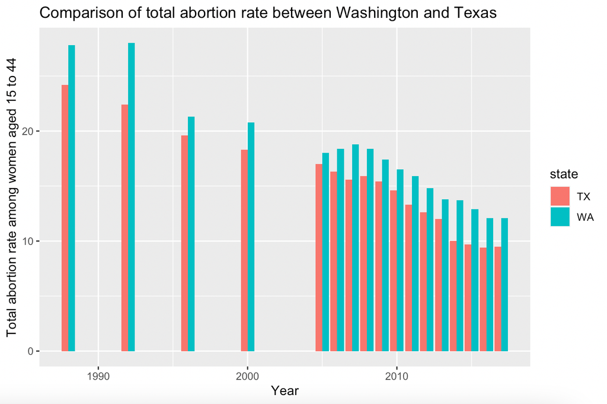

## Chart 3:

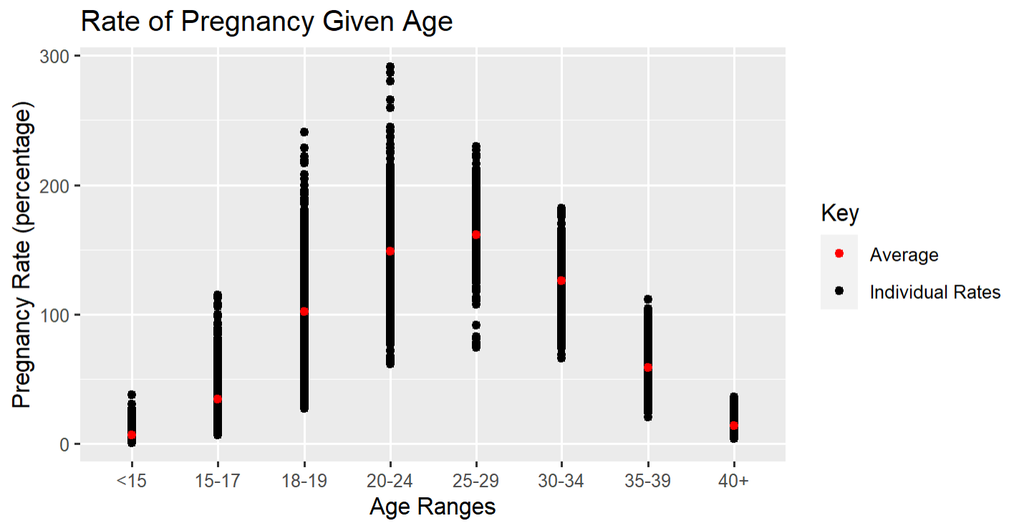

This chart is necessary in identifying the age ranges that had higher rates of pregnancy. As a result, this helps us answer questions concerning what age ranges will most likely be impacted by abortion restrictions. By gaining this information, we are able to possibly predict current statistics given Roe v. Wade’s overturn, causing restricted abortions. It seems that pregnancy rates are higher among people in their mid to late twenties, meaning that these rates may decrease in the future because these pregnancies may not have been planned. Consequently, less people may want to get pregnant because the option of an abortion may not be viable in their state given current circumstances.